# Connect1-Stigma: 3. Classification tree (missing data)

### Classification trees

**Method**

Another advantage of classification trees is that they can still work with missing data, whereas techniques such as logistic regression require that all variables be complete. To handle a dataset in which some observations are missing some variables, the algorithm first chooses the splitting rule (e.g. HHIE < 19 and HHIE ≥ 19) based only on observations with complete data for that variable. Once the splitting rule has been established, the algorithm then examines all other variables (age, PTA, …) and ranks them on how well they split the data just like the established rule. These will be “surrogate” variables for the observations that are missing data for the established rule. The top-ranked surrogate variable is the variable that behaves most like the established variable in sorting observations with complete data. Say for example that PTA is the top-ranked surrogate for HHIE; observations with missing HHIE data but present PTA data will be sorted using PTA. If the observation is also missing PTA in addition to missing HHIE, then the next best surrogate will be used to sort it (e.g. age), and so on. In the worst-case scenario, if an observation is missing all predictor variables, it will simply be sorted into the class with the majority of cases at that particular split.

The participants in this analysis were n=1396 who had a four-frequency PTA of > 25 dB HL in their better ear. 753 participants had complete data, while 643 participants had one or more missing observations in the 28 predictor variables (see below). All participants had known outcomes. For the classification tree model, I added case weights so that there was an “equivalent” number of ‘Yes’ and ‘No’ outcomes, so that the model would not be biased towards ‘No’ cases (‘Yes’ cases were weighted 1, and ‘No’ cases were weighted 0.2321).

Percentage of missing cells in each variable

```
##                   Age       PTA4_better_ear            HHIE_total
##                  0.00                  0.00                  5.09
##               Ability                   Sex                   Edu
##                  3.72                  0.00                  1.07
##               Married                Health                   QoL
##                 13.32                  1.79                  1.36
##       Help_neighbours         Help_problems               Concern
##                  1.07                  1.29                  3.22
##                Lonely           Sub_Age_avg        Age_stigma_avg
##                  1.07                  2.15                  3.72
##         HA_stigma_avg                Accomp        Soc_Suspect_HL
##                  1.29                  1.07                  4.37
##           Soc_Know_HL        Soc_Discuss_HL      Soc_Hearing_test
##                  4.23                  5.95                  9.24
##         Soc_Obtain_HA     Soc_Sometimes_use       Soc_Regular_use
##                  5.23                  9.38                  7.09
##     Soc_Very_positive Soc_Somewhat_positive Soc_Somewhat_negative
##                  9.74                 11.10                 10.82
##     Soc_Very_negative          Purchased_HA
##                 11.82                  0.00
```

**Results**

Plotting different subsets of the data, a model with about 15 splits or so had the lowest error.

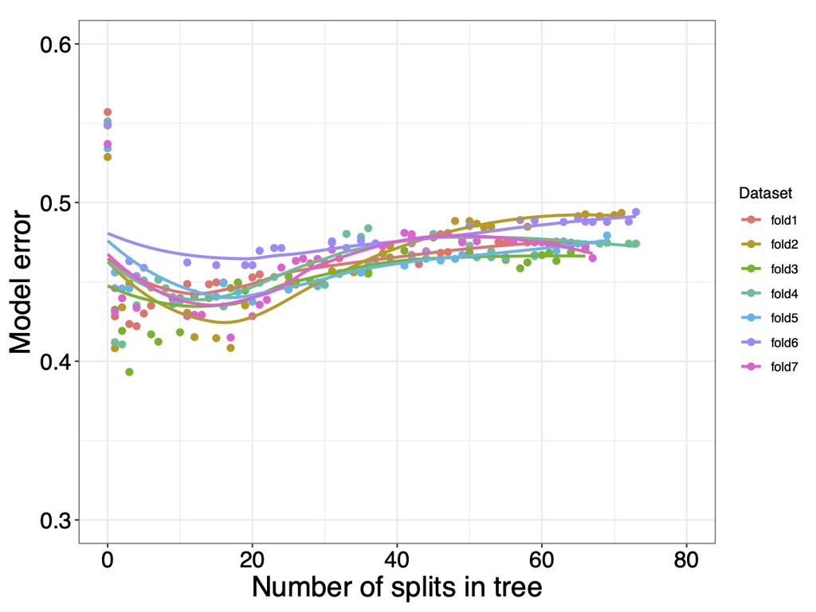

Using all the data and putting no limits on the complexity of the tree – the tree grew to 37 splits, with 77% accuracy, 88% sensitivity and 75% specificity.

[PDF of tree with 37 splits](https://huiwen-goy.github.io/connect1-stigma/tree_n1396_37splits.pdf)

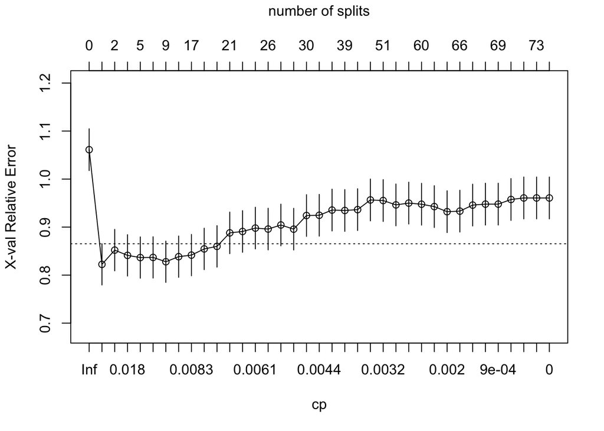

A tree with 2 splits has a depth of 2, 67% accuracy, 49% sensitivity, and 71% specificity, and uses two predictors: HHIE and Age.

[PDF of tree with depth 2](https://huiwen-goy.github.io/connect1-stigma/tree_n1396_depth2.pdf)

Increasing the maximum depth to 3 shows the effect of two social predictors (number of people available to help with serious problems, and loneliness). This tree has 5 splits, 64% accuracy, 62% sensitivity, and 64% specificity.

[PDF of tree with depth 3](https://huiwen-goy.github.io/connect1-stigma/tree_n1396_depth3.pdf)

Increasing the maximum depth to 4 shows additional social predictors. This tree has 8 splits, 70% accuracy, 57% sensitivity, and 72% specificity.

[PDF of tree with depth 4](https://huiwen-goy.github.io/connect1-stigma/tree_n1396_depth4.pdf)

**Conclusion**

Compared to a tree model based on 753 participants with complete data, a tree model based on 1396 participants with missing data performed more poorly on sensitivity. HHIE was still the top predictor, followed by Age, but the cut-off values changed slightly. The type of social predictors also changed slightly.